# Lab 5 Predicting Cardiovascular Health Outcomes Using Logistic Regression

Class 7 Classification with Logistic Regression

Tony Lim

# 1. Overview

The goal of this analysis is to develop a classification model with logistic regression to predict the 10-year risk of coronary heart disease (CHD) using the [Framingham Heart Study dataset](https://www.kaggle.com/amanajmera1/framingham-heart-study-dataset).

Install any necessary packages.

```r
list.of.packages <- c("caTools", "ROCR", "dplyr", "tidyverse")
new.packages <- list.of.packages[!(list.of.packages %in% installed.packages()[,"Package"])]
if(length(new.packages)) install.packages(new.packages)

library(caTools)
library(dplyr)
library(ROCR)
library(tidyverse)
```

Load the data file `framingham.csv` and convert `Education` to a factor variable.

```r
FRAMINGHAM <- read_csv("framingham.csv")
FRAMINGHAM$Education = as.factor(FRAMINGHAM$Education)
```

# 2. Data Summary

Let’s examine the Framingham dataset, which contains the following variables for each study participant:

**Outcome**

- **TenYearCHD:** patient has coronary heart disease (CHD) diagnosed within 10 years (1) or not (0)

**Demographics**

- **Male:** sex of patient (1 if male, 0 if female)
- **Age:** age in years at first examination
- **Education:** some high school (1), high school/GED (2), some college/vocational school (3), college grad (4)

**Behavioral risk factors**

- **Smoker:** whether patient currently smokes (1) or not (0)
- **CigsPerDay:** how many cigarettes smoked per day

**Medical history risk factors**

- **BPMeds:** on blood pressure medication (1) or not (0)
- **Stroke:** has patient previously had stroke (1) or not (0)
- **Hyper:** does patient currently have hypertension (1) or not (0)
- **Diabetes:** does patient currently have diabetes (1) or not (0)

**Risk factors from first examination**

- **TotChol:** total cholesterol (mg / dL)
- **SysBP:** systolic blood pressure
- **DiaBP:** diastolic blood pressure
- **BMI:** body mass index (weight / height^2)
- **HeartRate:** heart rate (beats per minute)
- **Glucose:** blood glucose level (mg / dL)

## Question 1

How many patients are included in the dataset? How many experienced CHD?

```r
FRAMINGHAM %>%
  print(width = Inf)
```

```
## # A tibble: 3,658 x 16
##     Male   Age Education Smoker CigsPerDay BPMeds Stroke Hyper Diabetes
##    <dbl> <dbl> <fct>      <dbl>      <dbl>  <dbl>  <dbl> <dbl>    <dbl>
##  1     1    39 4              0          0      0      0     0        0
##  2     0    46 2              0          0      0      0     0        0
##  3     1    48 1              1         20      0      0     0        0
##  4     0    61 3              1         30      0      0     1        0
##  5     0    46 3              1         23      0      0     0        0
##  6     0    43 2              0          0      0      0     1        0
##  7     0    63 1              0          0      0      0     0        0
##  8     0    45 2              1         20      0      0     0        0
##  9     1    52 1              0          0      0      0     1        0
## 10     1    43 1              1         30      0      0     1        0
##    TotChol SysBP DiaBP   BMI HeartRate Glucose TenYearCHD
##      <dbl> <dbl> <dbl> <dbl>     <dbl>   <dbl>      <dbl>
##  1     195  106     70  27.0        80      77          0
##  2     250  121     81  28.7        95      76          0
##  3     245  128.    80  25.3        75      70          0
##  4     225  150     95  28.6        65     103          1
##  5     285  130     84  23.1        85      85          0
##  6     228  180    110  30.3        77      99          0
##  7     205  138     71  33.1        60      85          1
##  8     313  100     71  21.7        79      78          0
##  9     260  142.    89  26.4        76      79          0
## 10     225  162    107  23.6        93      88          0
## # ... with 3,648 more rows
```

There are 3,658 patients in the `FRAMINGHAM` dataset.

```r
FRAMINGHAM %>%
  group_by(TenYearCHD) %>%
  count()
```

```
## # A tibble: 2 x 2
## # Groups:   TenYearCHD [2]
##   TenYearCHD     n
##        <dbl> <int>
## 1          0  3101
## 2          1   557
```

557 patients experienced CHD.

# 3. Training the Model

## Question 2

Split the dataset into training and test datasets, with 65% as training. We will first set the same seed.

```r
set.seed(88)

split <- sample.split(FRAMINGHAM$TenYearCHD, SplitRatio = 0.65)
```

```r
TRAIN <- FRAMINGHAM[split, ]
nrow(TRAIN)
```

```
## [1] 2378
```

```r
TEST <- FRAMINGHAM[!split, ]
nrow(TEST)
```

```
## [1] 1280
```

## Question 3

Run a logistic regression with `TenYearCHD` as the dependent variable and include all others as independent variables. Examine the odds ratios and confidence intervals. Which variables increase the risk of CHD and are statistically significant at 5%?

```r
logitCHD <- glm(TenYearCHD ~ .,
                data = TRAIN,
                family = "binomial")

summary(logitCHD)
```

```
##
## Call:
## glm(formula = TenYearCHD ~ ., family = "binomial", data = TRAIN)
##
## Deviance Residuals:
##     Min       1Q   Median       3Q      Max
## -1.3030  -0.5951  -0.4122  -0.2733   2.7539
##
## Coefficients:
##              Estimate Std. Error z value Pr(>|z|)
## (Intercept) -7.429443   0.858641  -8.653  < 2e-16 ***
## Male         0.661618   0.137831   4.800 1.58e-06 ***
## Age          0.061320   0.008296   7.392 1.45e-13 ***
## Education2  -0.142575   0.150465  -0.948 0.343349
## Education3  -0.189878   0.188445  -1.008 0.313644
## Education4  -0.174285   0.211484  -0.824 0.409881
## Smoker      -0.155994   0.197371  -0.790 0.429318
## CigsPerDay   0.026080   0.007566   3.447 0.000567 ***
## BPMeds       0.487889   0.274457   1.778 0.075461 .
## Stroke       0.044093   0.722833   0.061 0.951359
## Hyper        0.461626   0.170372   2.710 0.006738 **
## Diabetes    -0.045616   0.393852  -0.116 0.907795
## TotChol      0.002638   0.001376   1.917 0.055197 .
## SysBP        0.012837   0.004788   2.681 0.007332 **
## DiaBP       -0.009377   0.008007  -1.171 0.241546
## BMI         -0.014489   0.016269  -0.891 0.373137
## HeartRate   -0.000288   0.005186  -0.056 0.955710
## Glucose      0.008834   0.002997   2.948 0.003201 **
## ---
## Signif. codes:  0 '***' 0.001 '**' 0.01 '*' 0.05 '.' 0.1 ' ' 1
##
## (Dispersion parameter for binomial family taken to be 1)
##
##     Null deviance: 2028.7  on 2377  degrees of freedom
## Residual deviance: 1771.8  on 2360  degrees of freedom
## AIC: 1807.8
##
## Number of Fisher Scoring iterations: 5
```

```r
exp(cbind(OR = coef(logitCHD), confint(logitCHD)))
```

```
##                       OR        2.5 %      97.5 %
## (Intercept) 0.0005935182 0.0001085456 0.003149875
## Male        1.9379259295 1.4806380329 2.542472339
## Age         1.0632389167 1.0461803742 1.080782078
## Education2  0.8671220499 0.6442176879 1.162601214
## Education3  0.8270599210 0.5672216742 1.188928707
## Education4  0.8400577378 0.5487842209 1.259784265
## Smoker      0.8555644697 0.5787834637 1.255488308
## CigsPerDay  1.0264235205 1.0112800674 1.041767954
## BPMeds      1.6288745248 0.9430102742 2.774085132
## Stroke      1.0450792796 0.2137878056 3.990140440
## Hyper       1.5866521798 1.1353072524 2.214827448
## Diabetes    0.9554087527 0.4298594364 2.025116858
## TotChol     1.0026419749 0.9999229384 1.005339955
## SysBP       1.0129198753 1.0034414307 1.022471433
## DiaBP       0.9906663906 0.9752560763 1.006386372
## BMI         0.9856153707 0.9543944858 1.017302005
## HeartRate   0.9997120230 0.9895331139 1.009867668
## Glucose     1.0088731469 1.0030783240 1.014952048
```

The patient’s sex, age, number of cigarettes smoked per day, hypertension status, systolic blood pressure, and blood glucose levels are variables that increase the risk of CHD and are statistically significant at the 5% level.

# 4. Testing the Model

## Question 4

Using the `TEST` dataset, predict the probability of 10-year CHD. This will be stored as a new data array called `predictCHD.`

```r
predictCHD <- predict(logitCHD, newdata = TEST, type = "response")
```

## Question 5

In the `TRAIN` data, which outcome for `TenYearCHD` is most likely? Suppose we use this outcome as our prediction in a baseline model. What is the accuracy of a baseline model? Hint: use the `table()` function to see raw observation counts.

```r
table(TRAIN$TenYearCHD)
```

```
##
##    0    1
## 2016  362
```

In the `TRAIN` dataset, the most likely outcome for `TenYearCHD` is not having CHD (2,016 patients).

```r
table(TEST$TenYearCHD)
```

```
##
##    0    1
## 1085  195
```

```r
1085 / (1085 + 195)
```

```
## [1] 0.8476562
```

Therefore, if we used this outcome as our prediction in a baseline model, we get an accuracy of 84.8%.

## Question 6

Generate a confusion matrix, assuming a probability threshold of 0.5. What is the accuracy of the model using the `TEST` dataset?

```r
confusion <- table(TEST$TenYearCHD, predictCHD > 0.5)
confusion
```

```
##
##     FALSE TRUE
##   0  1078    7
##   1   184   11
```

```r
accuracy <- sum(diag(confusion)) / nrow(TEST)
accuracy
```

```
## [1] 0.8507813
```

The accuracy of the model using the `TEST` dataset is 85.1%.

## Question 7

Plot an ROC curve, and report the area under the curve (AUC).

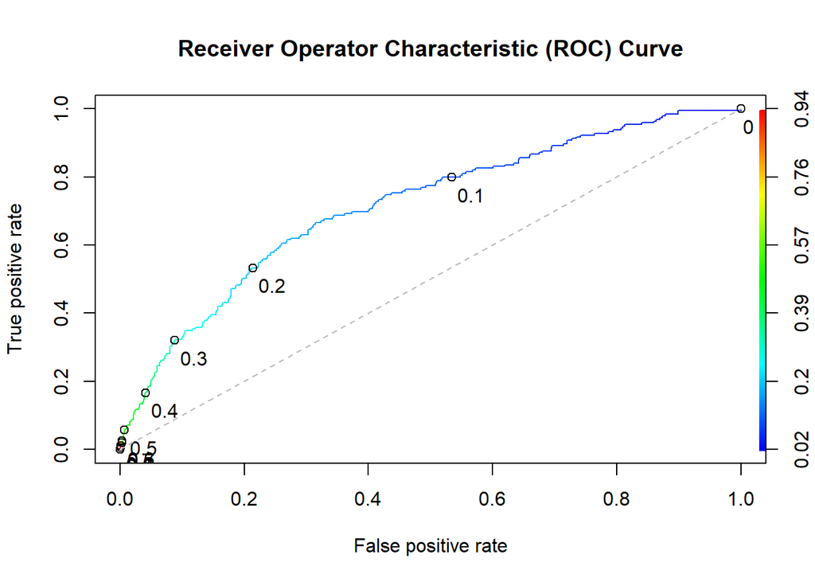

```r
ROCpred <- prediction(predictCHD, TEST$TenYearCHD)
ROCperf <- performance(ROCpred, "tpr", "fpr")

plot(ROCperf,
     main = "Receiver Operator Characteristic (ROC) Curve",
     colorize = TRUE,
     print.cutoffs.at = seq(0, 1, by = 0.1),
     text.adj = c(-0.2, 1.7))
lines(x = c(0, 1), y = c(0, 1), col = "gray", lty = "dashed", lwd = 1)
```

```r
AUC = as.numeric(performance(ROCpred, "auc")@y.values)
AUC
```

```
## [1] 0.714834
```

The dashed line or line of no-discrimination represents random chance (AUC = 0.50). For our model, the AUC is about 0.71, so it does better than random chance. Generally, an AUC of 0.70 to 0.80 is considered acceptable. Therefore, our model based on the logistic regression predicts relatively well which patient will have CHD given the other variables.